# Klasyfikacja

22.11.2019

# 1 Wprowadzenie

Mamy obserwacje $(x_{i1}, x_{i2}, \ldots, x_{ip}, y_i)$ dla $i \in \{1, 2, \dots, n\}$, gdzie $(x_{i1}, x_{i2}, \ldots, x_{ip})$ to cechy (atrybuty, zmienne objaśniające), a $y_i \in \{1, 2, \ldots, g\}$ to klasa.

W przypadku klasyfikacji binarne $y \in \{0,1\}$.

```r
library(OpenML)
library(ggplot2)

credit_task_openml <- getOMLDataSet(data.id = 31L)


df <- credit_task_openml$data
# iksy (wszystkie kolumny bez ostatniej) i igrek (ostatnia kolumna) w tabelce:
str(df)
```

```
## 'data.frame':    1000 obs. of  21 variables:
##  $ checking_status       : Factor w/ 4 levels "<0","0<=X<200",..: 1 2 4 1 1 4 4 2 4 2 ...
##  $ duration              : num  6 48 12 42 24 36 24 36 12 30 ...
##  $ credit_history        : Factor w/ 5 levels "no credits/all paid",..: 5 3 5 3 4 3 3 3 3 5 ...
##  $ purpose               : Factor w/ 11 levels "new car","used car",..: 4 4 7 3 1 7 3 2 4 1 ...
##  $ credit_amount         : num  1169 5951 2096 7882 4870 ...
##  $ savings_status        : Factor w/ 5 levels "<100","100<=X<500",..: 5 1 1 1 1 5 3 1 4 1 ...
##  $ employment            : Factor w/ 5 levels "unemployed","<1",..: 5 3 4 4 3 3 5 3 4 1 ...
##  $ installment_commitment: num  4 2 2 2 3 2 3 2 2 4 ...
##  $ personal_status       : Factor w/ 5 levels "male div/sep",..: 3 2 3 3 3 3 3 3 1 4 ...
##  $ other_parties         : Factor w/ 3 levels "none","co applicant",..: 1 1 1 3 1 1 1 1 1 1 ...
##  $ residence_since       : num  4 2 3 4 4 4 4 2 4 2 ...
##  $ property_magnitude    : Factor w/ 4 levels "real estate",..: 1 1 1 2 4 4 2 3 1 3 ...
##  $ age                   : num  67 22 49 45 53 35 53 35 61 28 ...
##  $ other_payment_plans   : Factor w/ 3 levels "bank","stores",..: 3 3 3 3 3 3 3 3 3 3 ...
##  $ housing               : Factor w/ 3 levels "rent","own","for free": 2 2 2 3 3 3 2 1 2 2 ...
##  $ existing_credits      : num  2 1 1 1 2 1 1 1 1 2 ...
##  $ job                   : Factor w/ 4 levels "unemp/unskilled non res",..: 3 3 2 3 3 2 3 4 2 4 ...
##  $ num_dependents        : num  1 1 2 2 2 2 1 1 1 1 ...
##  $ own_telephone         : Factor w/ 2 levels "none","yes": 2 1 1 1 1 2 1 2 1 1 ...
##  $ foreign_worker        : Factor w/ 2 levels "yes","no": 1 1 1 1 1 1 1 1 1 1 ...
##  $ class                 : Factor w/ 2 levels "good","bad": 1 2 1 1 2 1 1 1 1 2 ...
```

```r
cechy <- colnames(df)[-21]
klasa <- colnames(df)[21]

p <- ncol(df) - 1
n <- nrow(df)
```

My wybierzemy tylko cechy liczbowe:

```r
cechy <- colnames(df)[unlist(lapply(df, is.numeric))]
klasa <- colnames(df)[21]

p <- length(cechy)
n <- nrow(df)
```

Na podstawie próby uczącej chcemy podać reguł klasyfikacyjną, tzn. dla dowolnej nowej obserwacji $x = (x_1, x_2, \ldots, x_p)$ umieć podać jej klasę (czyli wartość $y$).

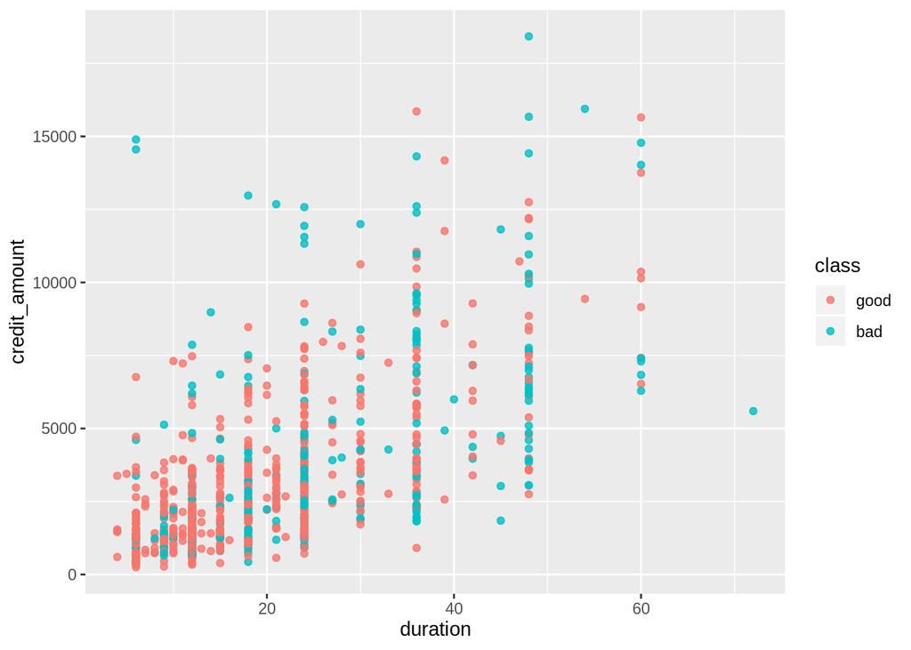

```r
ggplot(df, aes(x=duration, y = credit_amount, col = class))+
  geom_point(alpha = 0.8)
```

## 1.1 Podział na zbiór testowy i treningowy

Aby sprawdzic jak dobry jest model stosujemy podzial na zbior testowy i treningowy. Wtedy potrafimy ocenić czy model nie dopasował się za bardzo do danych uczących (przeuczył się) i daje też dobre wyniki na nowych danych.

Próba ucząca:

```r
set.seed(123)
id_train <- sample(1:n, 3/4 * n)
df_train <- df[id_train, c(cechy, klasa)]
```

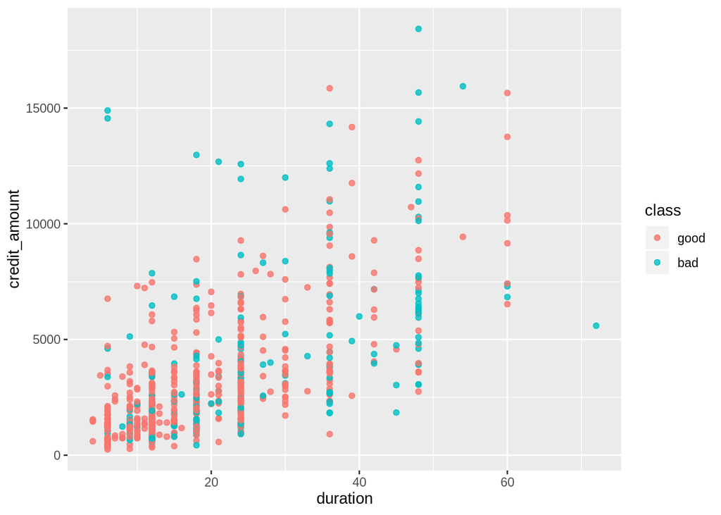

```r
ggplot(df_train, aes(x=duration, y = credit_amount, col = class))+
  geom_point(alpha = 0.8)
```

Pozostałe obserwacje (dla nich będziemy przewidywać klasę):

```r
id_test <- setdiff(1:n, sample(1:n, 3/4 * n))
df_test <- df[id_test, c(cechy, klasa)]
```

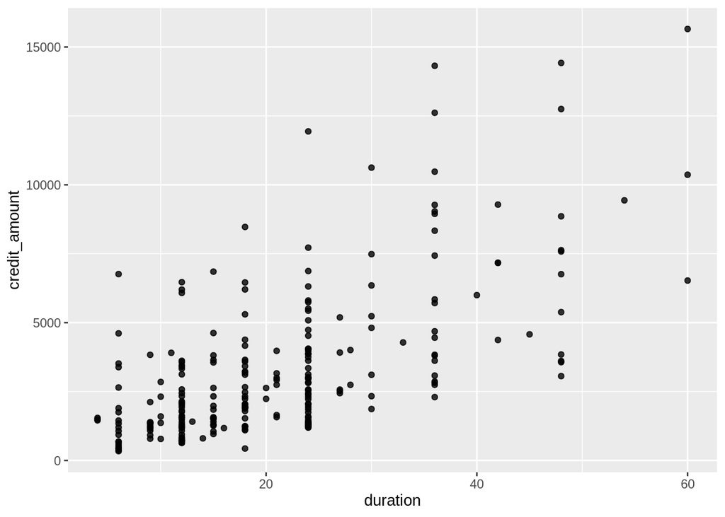

```r
ggplot(df_test, aes(x=duration, y = credit_amount))+
  geom_point(alpha = 0.8)
```

# 2 Metody klasyfikacji

Różne algorytmy klasyfikacyjne jako predykcję modelu mogą zwracać: * prawdopodobieństwo przynależności do klasy * klasę

## 2.1 Regresja logistyczna

Najbardziej tradycyjne podejście do problemu klasyfikacji. Jedną z motywacji jest to, że chcemy przewidzieć prawdopodobieństwo przynależności do klasy 1 zatem predykcja modelu powinna spełniać $0 \leq f(x) \leq 1$.

Jednym z przykładów funkcji, która spełnia takie ograniczenie jest funkcja logistyczna
$$f(x) = \frac{e^x}{1+e^x}$$

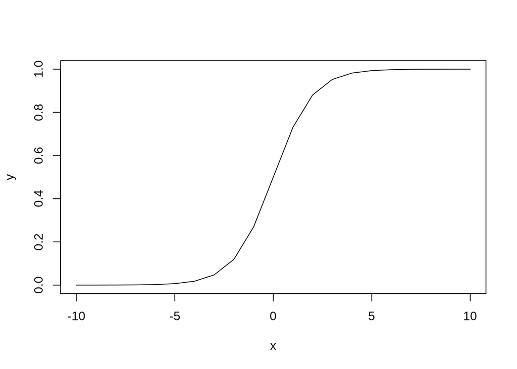

W algorytmie regresji logistycznej są funcje logistycze od kombinacji liniowej zmiennej objaśniających.

$$\hat{P}(Y=1|X=x)=\hat{P}(Y=1|X_1=x_1, \ldots, X_p=x_p) = \frac{\exp(\alpha + \beta'x)}{1+\exp(\alpha + \beta'x)}$$

$$\hat{P}(Y=0|X=x)=\hat{P}(Y=0|X_1=x_1, \ldots, X_p=x_p) = \frac{1}{1+\exp(\alpha + \beta'x)}$$

W procesie trenowanie modelu obliczane są współczynniki: $\beta = (\beta_1, ..., \beta_p)$ i $\alpha$.

```r
logistic_classifier <- glm(class~duration+credit_amount, data=df_train, family = binomial(link = "logit"))
logistic_classifier
```

```
##
## Call:  glm(formula = class ~ duration + credit_amount, family = binomial(link = "logit"),
##     data = df_train)
##
## Coefficients:
##   (Intercept)       duration  credit_amount
##    -1.662e+00      3.228e-02      2.091e-05
##
## Degrees of Freedom: 749 Total (i.e. Null);  747 Residual
## Null Deviance:       905.9
## Residual Deviance: 874.3     AIC: 880.3
```

Predykcje z modelu:

```r
predict(logistic_classifier, newdata=df_test[,cechy], type="response")[20:30]
```

```
##        78        84        87        96       100       104       105       106
## 0.5691746 0.2156922 0.4412163 0.2257064 0.2980389 0.2272928 0.3457581 0.2796824
##       107       108       110
## 0.2409109 0.3260909 0.1918247
```

Jeśli chcemy dopasować model ze wszystkimi zmiennymi objaśniającymi wystarczy w formule wpisać `class ~ .`

```r
logistic_classifier_2 <- glm(class~., data=df_train, family = binomial(link = "logit"))
logistic_classifier_2
```

```
##
## Call:  glm(formula = class ~ ., family = binomial(link = "logit"), data = df_train)
##
## Coefficients:
##            (Intercept)                duration           credit_amount
##             -1.679e+00               2.464e-02               6.818e-05
## installment_commitment         residence_since                     age
##              2.184e-01               1.511e-02              -1.216e-02
##       existing_credits          num_dependents
##             -3.378e-01               1.835e-01
##
## Degrees of Freedom: 749 Total (i.e. Null);  742 Residual
## Null Deviance:       905.9
## Residual Deviance: 860   AIC: 876
```

Istnieje jescze rozszerzona wersja tego moodelu gdzie nakłada się dodatkowe ograniczenia na współczynniki modelu $\beta$ - regresja logistyczna z regularyzacją.

```r
library(glmnet)
logistic_classifier_reg <- glmnet(x = as.matrix(df_train[, cechy]), y = df_train[,'class'],
                                  family = 'binomial',
                                  alpha = 0.5,
                                  lambda = 0.1)

coefficients(logistic_classifier_reg)
```

```
## 8 x 1 sparse Matrix of class "dgCMatrix"
##                                 s0
## (Intercept)            -1.17693798
## duration                0.01369514
## credit_amount           .
## installment_commitment  .
## residence_since         .
## age                     .
## existing_credits        .
## num_dependents          .
```

Parametry: `lambda`, `alpha`

## 2.2 SVM

Chcemy znaleźć najlepiej płaszczyznę najlepiej rozdzielającą obserwacje należące do różnych klas. Chcemy maksymalizować odległość obserwacji od tej płaszczyzny, a równocześnie każemy za popełnione błędy.

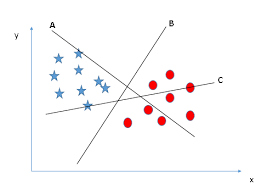

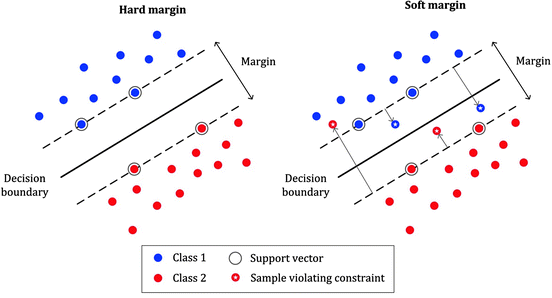

```r
library(e1071)

svm_model <- svm(class~.,data=df_train, kernel='linear',  cost=100, probability = TRUE)
svm_model
```

```
##
## Call:
## svm(formula = class ~ ., data = df_train, kernel = "linear", cost = 100,
##     probability = TRUE)
##
##
## Parameters:
##    SVM-Type:  C-classification
##  SVM-Kernel:  linear
##        cost:  100
##
## Number of Support Vectors:  581
```

```r
predict(svm_model, newdata = df_test, probability = TRUE)[1:20]
```

```
##    2    6    9   12   14   15   21   23   30   40   42   46   49   52   56   60
## good good good good good good good good good good good good good good good good
##   61   63   65   78
## good good good good
## Levels: good bad
```

Isnieje też rozszerzenie tej metody, w której dane poddawane są przekształceniom zdefiniowanym przez parametr `kernel`.

Parametry: * `kernel` - rodzaj przekształcenia, * `gamma` - dodatkowy parametr związany z przekształceniem zdefiniowanym przez `kernel`, * `cost` - parametr kary za błędy.

## 2.3 $k$ najbliższych sąsiadów (kNN)

Przewidywanie klasy nowej obserwacji na podstawie $k$ najbliższych obserwacji z próby uczącej. Stosowana jest reguła większościowa.

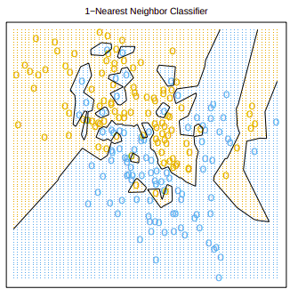

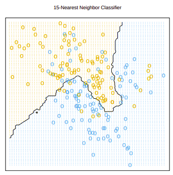

```r
library(class) # albo np. biblioteka FNN

knn_classifier <- knn(train=df_train[, cechy],
                      cl=df_train$class,
                      test=df_test[, cechy],
                      k=10,
                      use.all=TRUE)
knn_classifier[1:10]
```

```
##  [1] good good good good good good good bad  good good
## Levels: good bad
```

Można też stosować uproszczoną metodę estymacji prawodopodobieństwa na zasadzie frakcji sąsiadów należących do określonej klasy.

```r
knn_classifier <- knn(train=df_train[, cechy],
                      test=df_test[, cechy], cl=df_train[, klasa], k=10, prob=TRUE, use.all=TRUE)
# prawdopodobieństwo przynależności obserwacji do klasy
knn_classifier[1:10] # klasa
```

```
##  [1] good good good good good good good bad  good good
## Levels: good bad
```

```r
attributes(knn_classifier)$prob[1:10] # p-stwo
```

```
##  [1] 0.7 0.9 0.6 1.0 0.9 0.7 0.7 0.6 0.7 0.8
```

Parametry: $k$

## 2.4 modele oparte na drzewach decyzyjnych

### 2.4.1 Drzewo klasyfikacyjne

$m$ - rodzic, $m_L$ - lewe dziecko, $m_R$ - prawe dziecko

$Q_m$ - miara różnorodności dla $m$ (Gini, entropia)

$\hat{p}_L$ - liczba obserwacji w węźle $m_L$ dzielona przez liczbę obserwacji w węźle $m$, analogicznie $\hat{p}_R$

$$\Delta Q_{m, m_L, m_R} = Q_m - (\hat{p}_LQ_{m_L} + \hat{p}_RQ_{m_R})$$

Chcemy tak wybierać podziały, żeby maksymalizować $\Delta Q_{m, m_L, m_R}$.

Predykcja w ostatnim weźle (liściu) jest robiona na podstawie reguły większościowej

```r
library(rpart)
tree_classifier <- rpart(class~., data=df_train)
```

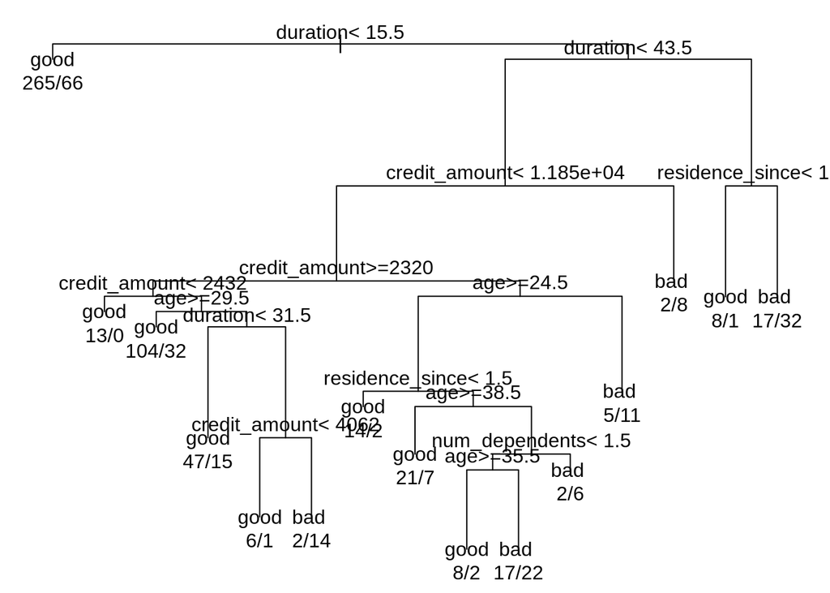

```r
par(mar=c(1,1,1,1))
par(xpd=TRUE)

plot(tree_classifier)
text(tree_classifier, use.n=TRUE)
```

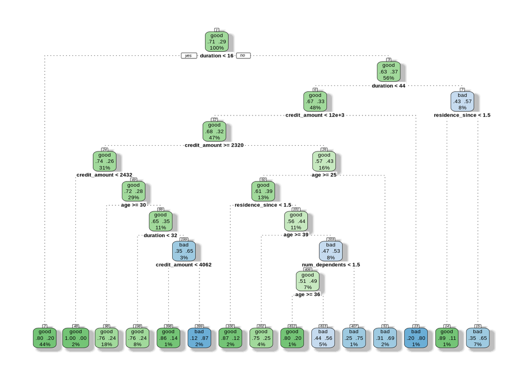

```r
# pomoc: ?plot.rpart, ?text.rpart

library(rattle)
fancyRpartPlot(tree_classifier, caption = NULL)
```

```r
predict(tree_classifier, newdata=df_test[,cechy], type="class")[1:20]
```

```
##    2    6    9   12   14   15   21   23   30   40   42   46   49   52   56   60
## good good good good good  bad good good good good good good good good good good
##   61   63   65   78
## good  bad good  bad
## Levels: good bad
```

```r
predict(tree_classifier, newdata=df_test[,cechy], type="prob")[1:20,]
```

```
##         good       bad
## 2  0.8006042 0.1993958
## 6  0.7647059 0.2352941
## 9  0.7580645 0.2419355
## 12 0.8006042 0.1993958
## 14 0.8006042 0.1993958
## 15 0.4358974 0.5641026
## 21 0.8006042 0.1993958
## 23 0.8006042 0.1993958
## 30 0.8000000 0.2000000
## 40 1.0000000 0.0000000
## 42 0.7647059 0.2352941
## 46 0.7500000 0.2500000
## 49 0.8006042 0.1993958
## 52 0.8006042 0.1993958
## 56 0.8006042 0.1993958
## 60 0.8006042 0.1993958
## 61 0.8006042 0.1993958
## 63 0.3469388 0.6530612
## 65 0.7647059 0.2352941
## 78 0.3469388 0.6530612
```

Parametry:

- na jakim poziomie skoćczyć dzielenie (rpart.control):
  - minsplit - the minimum number of observations that must exist in a node in order for a split to be attempted
  - cp - parametr przycinania
- na podstawie jakiego kryterium (gini lub information)

$T$ - drzewo $R(T)$ - frakcja obserwacji, które źle zaklasyfikowaliśmy $cp = \alpha$
$$R_{\alpha}(T) = R(T) + \alpha |T|$$

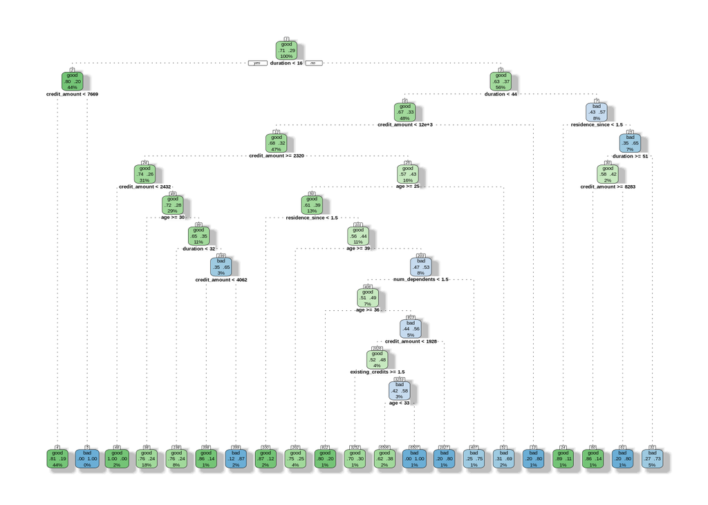

```r
tree_classifier_parameter_change <- rpart(class~., data=df_train,
  parms = list(split = 'information'),
  minsplit = 10,
  cp = 0.01)
fancyRpartPlot(tree_classifier_parameter_change, caption = NULL)
```

### 2.4.2 lasy losowe

Lasy losowe są przykładem komitetu klasyfikatorów. Polegają na niezależnym tworzeniu `ntrees` drzew decyzyjnych. Z każdego drzewa decyzyjnego otrzymujemy predykcję. Ostateczna predykcja jest średnią wszystkich predykcji.

```r
library(ranger)
rf_classifier <- ranger(class~., data=df_train)

rf_classifier
```

```
## Ranger result
##
## Call:
##  ranger(class ~ ., data = df_train)
##
## Type:                             Classification
## Number of trees:                  500
## Sample size:                      750
## Number of independent variables:  7
## Mtry:                             2
## Target node size:                 1
## Variable importance mode:         none
## Splitrule:                        gini
## OOB prediction error:             27.73 %
```

Parametry:

- `num.tree` - liczba budowanych drzew
- `max_depth` - maksymalna głębokość drzewa
- `min.node.size` - minimalna ilość obserwacji w weźle
- `splitrule` - metoda podziału w węźle

### 2.4.3 Gradient boosting i xgboost

Metody oparte na gradient boostingu polegają na budowaniu kolejnych modeli (zwykle dość prostych - weak classifiers) na przybliżonych rezyduach z poprzednich modeli. Zwykle tymi klasyfikatorami są drzewa.

```r
library(gbm)

df_train_numeric <- df_train
df_train_numeric[,klasa] <- ifelse(df_train_numeric[,klasa] == 'good', 1, 0)

gbm_classifier <- gbm(class~., data=df_train_numeric)
```

```
## Distribution not specified, assuming bernoulli ...
```

```r
gbm_classifier
```

```
## gbm(formula = class ~ ., data = df_train_numeric)
## A gradient boosted model with bernoulli loss function.
## 100 iterations were performed.
## There were 7 predictors of which 7 had non-zero influence.
```

Parametry:

- `n.trees`
- `interaction.depth`
- `n.minobsinnode`
- `shrinkage`
- `bag.fraction`

# 3 Metody oceny

## 3.1 Miary

```r
tree_classifier_test_prediction_class <- predict(tree_classifier, newdata = df_test, type = 'class')
tree_classifier_test_prediction_class <- factor(ifelse(tree_classifier_test_prediction_class == 'good', 'PRED_GOOD', 'PRED_BAD'), levels = c('PRED_GOOD', 'PRED_BAD'))
tree_classifier_test_prediction_proba <- as.data.frame(predict(tree_classifier, newdata = df_test, type = 'prob'))
```

### 3.1.1 Miary oparte na predykcji klasy

#### 3.1.1.1 confusion matrix

Macierz błędów - zliczamy ile obserwacji w każdej z grup zostało poprawnie zaklasyfikowanych

```r
table('Reference'= df_test$class, 'Prediction' = tree_classifier_test_prediction_class)
```

```
##          Prediction
## Reference PRED_GOOD PRED_BAD
##      good       153       15
##      bad         57       25
```

Rodzaje obserwacji:

TP - True Positive - obserwacje poprawnie zaklasyfikowane do klasy pozytywnej TN - True Negative - obserwacje poprawnie zaklasyfikowane do klasy negatynwej

FP - False Positive - obserwacje niepoprawnie zaklasyfikowane do klasy pozytywnej FN - False Negative - obserwacje niepoprawnie zaklasyfikowane do klasy negatynwej

```r
type_of_error <- ifelse(df_test$class=='bad' & tree_classifier_test_prediction_class=='PRED_BAD', "TN",
                      ifelse(df_test$class=='bad' & tree_classifier_test_prediction_class=='PRED_GOOD', "FP",
                       ifelse(df_test$class=='good' & tree_classifier_test_prediction_class=='PRED_BAD', "FN", "TP")))

#Create raw confusion matrix using "table" function
(conf.val <- table(type_of_error))
```

```
## type_of_error
##  FN  FP  TN  TP
##  15  57  25 153
```

#### 3.1.1.2 Accuracy - dokładność

Jaki procent wszystkich obserwacji został dobrze zaklasyfikowany

```r
accuracy <- (conf.val['TP']+conf.val['TN'])/sum(conf.val)
accuracy
```

```
##    TP
## 0.712
```

#### 3.1.1.3 Classification error rate function - procent błędu

JAki procent wszystkich obserwacji został źle zaklasyfikowany

```r
error_rate <- (conf.val['FP']+conf.val['FN'])/sum(conf.val)
error_rate
```

```
##    FP
## 0.288
```

#### 3.1.1.4 Precision function - precyzja

Jaki procent obserwacji zaklasyfikowanych jako pozytywne, faktycznie należy do tej klasy

```r
precision <- (conf.val['TP'])/(+conf.val['TP']  +conf.val['FP'])
precision
```

```
##        TP
## 0.7285714
```

#### 3.1.1.5 Sensitivity function (recall)

Jaki procent obserwacji pozytywnych został zaklasyfikowany do tej klasy

```r
recall <- (conf.val['TP'])/(conf.val['TP']  +conf.val['FN'])
recall
```

```
##        TP
## 0.9107143
```

#### 3.1.1.6 Specificity function

Jaki procent obserwacji negatywnych został zaklasyfikowany do tej klasy

```r
specificity <- (conf.val['TN'])/(conf.val['TN']  +conf.val['FP'])
specificity
```

```
##       TN
## 0.304878
```

#### 3.1.1.7 F1

Średnia harmoniczna precyzji i recall
$$F_1 = 2* \frac{precision \times recall}{precision + recall}$$

```r
F_1 <- 2* precision* recall/(precision + recall)
F_1
```

```
##        TP
## 0.8095238
```

### 3.1.2 Miary oparte na predykcji prawdopodobieństwa

#### 3.1.2.1 Krzywa ROCR

Ten wykres jest funkcją punktu odcięcia - jeśli model przewidzi prawdopodobieństwo powyżej tej wartości to klasyfikujemy ją do klasy pozytywnej.

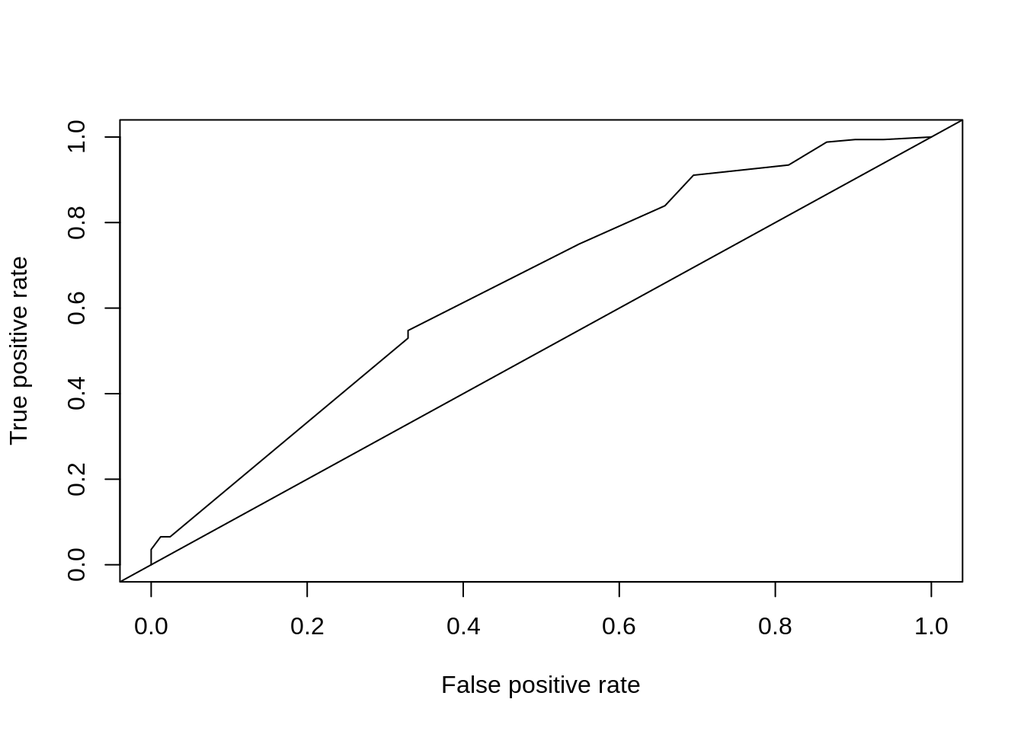

```r
library(ROCR)

pred <- prediction(tree_classifier_test_prediction_proba$good,df_test$class=='good')
roc.perf = performance(pred, measure = "tpr", x.measure = "fpr")
plot(roc.perf)
abline(a=0, b= 1)
```

Im wykres jest bardziej *stromy* tym lepiej.

#### 3.1.2.2 AUC

Jest to pole pod krzywą ROC. Im bliższe wartości 1 tym model jest lepszy.

```r
auc.perf = performance(pred, measure = "auc")
auc.perf@y.values
```

```
## [[1]]
## [1] 0.6466318
```

### 3.1.3 Jaką miarę wybrać?

Podzczas trenowania modeli najlepiej zwracać uwagę na wszystkie wymienione miary. Jeśli nasze dane są zbilansowane możemy używać dowolnej miary - najbardziej polecana jest miara AUC. Jeśli dane nie są zbilensowane- jest duża różnica pomiędzy licznością klasy negatywnej i pozytywnej , trzeba uważać na Accuracy. Trzeba patrzeć na precyzję i recall.

## 3.2 Kroswalidacja

Aby lepiej oceniać stabilność jakośni modeli na danych treningowych stosuje się kroswalidację - cały zbiór danych treningowy dzielimy na $k$ - podzbiorów. W każdej iteracji uczymy algorytm na $k-1$ podzbiorach a testujemy na pozostałym jednym zbiorze danych.

Jako ocenę jakości modeli możemy stosować każdą z wyżej wymienionych miar.

Jeśli model jest dobrze przygotowany to błąd, który uzyskamy na zbiorze testowym (który nie był wykorzystywany w kroswalidacji) powiniem być zbliżony do średnigo błędu z kroswalidacji.

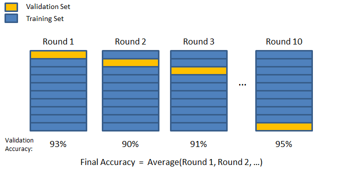

Część modeli ma dostępną kroswalidację jako osobny argument np. `gbm` czy `xgboost`, dla pozostałych trzeba to robić ręcznie. Można też skorzystać ze pakietów `caret` czy `mlr`.

# 4 Brakujace dane

Większość z wyżej wymienionych algortmów nie radzi sobie z brakami danych. Musimy je wcześniej uzupełnić lub usunąć.

**Gdy będziecie stosować techniki imputacji danych ważne jest aby ze zbioru usunąć zmienną odpowiedzi.** Wetdy unikamy sytuacji, że model imputacji korzysta z informacji o zmiennej którą ma przewidywać i nie prowadzi to do wycieku danych (leakage).

W przypadku wypełniania brakujących danych, na jakość predykcji wpływa nie tylko algorytm ale także metoda uzupełniania braków (imputacja).

Aby najlepiej oceniać techniki imputacji i algorytmy uczenia maszynowego najlepszym podejściem jest wyznaczenie wartości, którą będziemy wypełniać na zbiorze treningowym - może być to jedna wartość lub model, na podstawie, którego wypełniamy braki. Następnie powinniśmy wykorzystać te wartości lub nauczone modele do imputacji na zbiorze testowym. Niestety większość metod imputacji braków danych w R nie pozwala zapisać tego obiektu modelowego. Uniemożliwia to więc przeprowadzenie w poprawnej kroswalidacji i oceny na zbiorze testowym.

Możemy zastosować uproszczenie procesu: 1. stosujemy imputację na całym zbiorze treningowym 2. dzielimy uzupełniony zbiór treningowy na podzbiory i przeprowadzamy kroswalidację 3. stosujemy imputację na zbiorze testowym 4. Oceniamy algorytm na zbiorze testowym